# Tarea 4

Arqueología Cuantitativa

Esteban Arroyo

20-10-2022

## Primero Definimos nuestra carpeta de trabajo

```r
setwd("C:/Users/usuario/Desktop/Arqueología Cuantitativa/Tareas/Tarea4")
```

## Cargamos nuestra librería y cargamos la base de datos

```r
library(readxl)
data_set1 <- read_excel("Base_de_datos_trabajo_4_2022.xlsx", sheet="Niveles")
data_set2 <- read_excel("Base_de_datos_trabajo_4_2022.xlsx", sheet="Sitios")
```

## Cargamos las librerías que vamos a usar

```r
library(nortest)
library(lmtest)
library(fBasics)
```

```r
library(ggplot2)
library(flextable)
library(dplyr)
```

# Hacemos un preview de nuestros datos

```r
head(data_set1) %>% flextable() %>% set_caption("Base Niveles") %>%
  bg(bg="#0E6655", part = "header") %>% bold(part = "header") %>%
  color(color = "white", part = "header") %>% autofit()
```

Base Niveles

| Nivel | Densidad líticos | Densidad óseos |
| --- | --- | --- |
| 1 | 908 | 900 |
| 2 | 890 | 863 |
| 3 | 782 | 662 |
| 4 | 670 | 964 |
| 5 | 587 | 759 |
| 6 | 546 | 703 |

```r
head(data_set2) %>% flextable() %>% set_caption("Base Sitios") %>%
  bg(bg="#0E6655", part = "header") %>% bold(part = "header") %>%
  color(color = "white", part = "header") %>% autofit()
```

Base Sitios

| Dist(km) | Altitud (msnm) | %Obs |
| --- | --- | --- |
| 15 | 3,240 | 90 |
| 25 | 3,300 | 88 |
| 12 | 3,150 | 80 |
| 60 | 3,000 | 60 |
| 7 | 3,450 | 91 |
| 56 | 4,500 | 92 |

## **Ejercicio 1**

### En la hoja “Niveles” se encuentra la información de densidad de restos líticos y óseos en los niveles de un mismo sitio arqueológico (niveles artificiales cada 5 cms). Queremos saber si existe una correlación entre la profundidad y la densidad de restos para ambas categorías materiales. Para la anterior, efectúe lo siguiente:

### a) Desarrolle las pruebas de correlación que sean más apropiadas para cada caso, definiendo su intensidad y significancia. No olvide comprobar los supuestos que correspondan antes de aplicar las pruebas. ¿Existe una correlación entre profundidad y densidad de restos líticos y óseos? ¿qué dirección adquiere esta relación? ¿Cuál tipo de material posee la correlación más intensa con la profundidad?

### Para este caso aplicamos Spearman dado que Nivel es una variable ordinal

```r
cor1 <- cor.test(x=data_set1$Nivel, y=data_set1$`Densidad líticos`, method="spearman", exact=FALSE)
cor1 %>% as_flextable() %>%
  set_caption("Correlación de Spearman entre NIvel y Densidad líticos") %>%
  bg(bg="#2874A6", part = "header") %>% bold(part = "header") %>%
  color(color = "white", part = "header") %>%
  colformat_double(j= ~ estimate, digits = 4) %>% set_header_labels(estimate = "Estimate", statistic = "Statistic", p.value = "P-value", method = "Method", alternative = "Alternative")%>%
  add_footer_lines("Fuente: Esteban Arroyo") %>% autofit()
```

Correlación de Spearman entre NIvel y Densidad líticos

| Estimate | Statistic | P-value | Method | Alternative |
| --- | --- | --- | --- | --- |
| -0.8563 | 4,269.4 | 0.0000*** | Spearman's rank correlation rho | two.sided |

Signif. codes: 0 <= '***' < 0.001 < '**' < 0.01 < '*' < 0.05  
Fuente: Esteban Arroyo

```r
cor2 <- cor.test(x=data_set1$Nivel, y=data_set1$`Densidad óseos`, method="spearman", exact=FALSE)
cor2 %>% as_flextable() %>%
  set_caption("Correlación de Spearman entre NIvel y Densidad óseos") %>%
  bg(bg="#2874A6", part = "header") %>% bold(part = "header") %>%
  color(color = "white", part = "header") %>%
  colformat_double(j= ~ estimate, digits = 4) %>%
  set_header_labels(estimate = "Estimate", statistic = "Statistic", p.value = "P-value", method = "Method", alternative = "Alternative")%>%
  add_footer_lines("Fuente: Esteban Arroyo") %>% autofit()
```

Correlación de Spearman entre NIvel y Densidad óseos

| Estimate | Statistic | P-value | Method | Alternative |
| --- | --- | --- | --- | --- |
| -0.9765 | 4,546.0 | 0.0000*** | Spearman's rank correlation rho | two.sided |

Signif. codes: 0 <= '***' < 0.001 < '**' < 0.01 < '*' < 0.05  
Fuente: Esteban Arroyo

### ¿Existe una correlación entre profundidad y densidad de restos líticos y óseos?

## Sí. en ambos casos la correlación es alta.

### ¿Qué dirección adquiere esta relación?

## En ambos casos la correlación es negativa

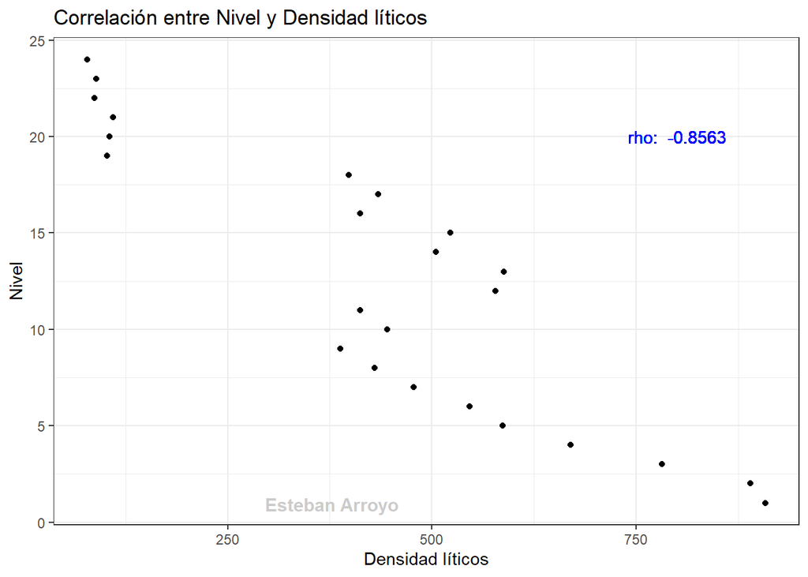

```r
ggplot(data_set1, aes(x = `Densidad líticos`, y = Nivel)) + geom_point() + theme_bw() + ggtitle("Correlación entre Nivel y Densidad líticos") + annotate("text",x=Inf,y=-Inf,label="Esteban Arroyo",hjust=4,vjust=-1,col="grey",cex=4,fontface = "bold", alpha = 0.8) + geom_text(x = 800, y = 20, label = paste("rho: ", round(cor1$estimate, 4)), col="blue"  )
```

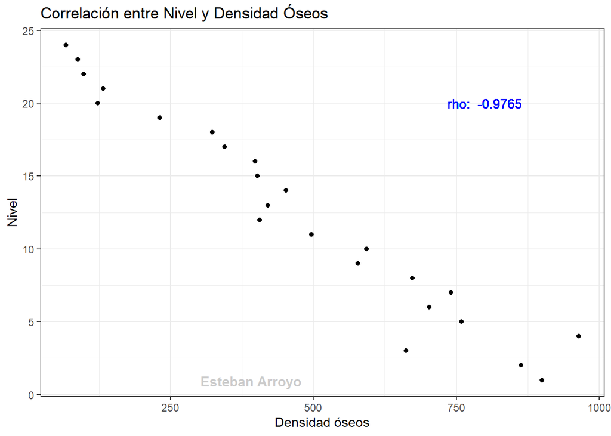

```r
ggplot(data_set1, aes(x = `Densidad óseos`, y = Nivel)) + geom_point() + theme_bw() + ggtitle("Correlación entre Nivel y Densidad Óseos") + annotate("text",x=Inf,y=-Inf,label="Esteban Arroyo",hjust=4,vjust=-1,col="grey",cex=4,fontface = "bold", alpha = 0.8) + geom_text(x = 800, y = 20, label = paste("rho: ", round(cor2$estimate, 4)), col="blue"  )
```

### ¿Cuál tipo de material posee la correlación más intensa con la profundidad?

## La correlación más intensa se dá entre el nivel y Densidad óseos **(-0.9765)**, pero inversa, es decir, a medida que la densidad ósea aumenta, el nivel de profundidad es menor

### b) Desarrolle también las pruebas que correspondan para definir si existe una correlación entre restos óseos y líticos.¿es posible establecer un modelo de regresión que prediga la densidad de restos óseos en base a la densidad de líticos? (justifique y exponga los datos correspondientes)

### En este caso como ambas variables son contínuas numéricas, comprobamos la normalidad de los datos

```r
lillie.test(data_set1$`Densidad óseos`) %>% as_flextable() %>%
  set_caption("Prueba de Normalidad Lilliefors (Kolmogorov-Smirnov) para Densidad óseos")%>%
  bg(bg="#D4AC0D", part = "header") %>% bold(part = "header") %>%
  colformat_double(j= ~ statistic, digits = 4)%>%
  add_footer_lines("Fuente: Esteban Arroyo") %>% autofit()
```

Prueba de Normalidad Lilliefors (Kolmogorov-Smirnov) para Densidad óseos

| statistic | p.value | method |
| --- | --- | --- |
| 0.1058 | 0.6952 | Lilliefors (Kolmogorov-Smirnov) normality test |

Signif. codes: 0 <= '***' < 0.001 < '**' < 0.01 < '*' < 0.05  
Fuente: Esteban Arroyo

```r
lillie.test(data_set1$`Densidad líticos`) %>% as_flextable() %>%
  set_caption("Prueba de Normalidad Lilliefors (Kolmogorov-Smirnov) para Densidad líticos")%>%
  bg(bg="#D4AC0D", part = "header") %>% bold(part = "header") %>%
  colformat_double(j= ~ statistic, digits = 4)%>%
  add_footer_lines("Fuente: Esteban Arroyo") %>% autofit()
```

Prueba de Normalidad Lilliefors (Kolmogorov-Smirnov) para Densidad líticos

| statistic | p.value | method |
| --- | --- | --- |
| 0.1675 | 0.0802 . | Lilliefors (Kolmogorov-Smirnov) normality test |

Signif. codes: 0 <= '***' < 0.001 < '**' < 0.01 < '*' < 0.05  
Fuente: Esteban Arroyo

### Como ambas variables se ajustan a la normal, procedemos a calcular la correlación con el metodo de Pearson

```r
cor3 <- cor.test(x=data_set1$`Densidad óseos`, y=data_set1$`Densidad líticos`, method="pearson")
cor3 %>% as_flextable() %>% set_caption("Correlación de Pearson entre Densidad óseos y Densidad líticos") %>%
  bg(bg="#2874A6", part = "header") %>% bold(part = "header") %>%
  color(color = "white", part = "header") %>%
  colformat_double(j= ~ estimate, digits = 3) %>%
  set_header_labels(estimate = "Estimate", statistic = "Statistic", p.value = "P-value", parameter = "Parameter", conf.low = "Conf Low", conf.high = "Conf High",  method = "Method", alternative = "Alternative")%>%
  add_footer_lines("Fuente: Esteban Arroyo") %>% autofit()
```

Correlación de Pearson entre Densidad óseos y Densidad líticos

| Estimate | Statistic | P-value | Parameter | Conf Low | Conf High | Method | Alternative |
| --- | --- | --- | --- | --- | --- | --- | --- |
| 0.867 | 8.1 | 0.0000*** | 22 | 0.7 | 0.9 | Pearson's product-moment correlation | two.sided |

Signif. codes: 0 <= '***' < 0.001 < '**' < 0.01 < '*' < 0.05  
Fuente: Esteban Arroyo

### Hacemos el gráfico de dispersión

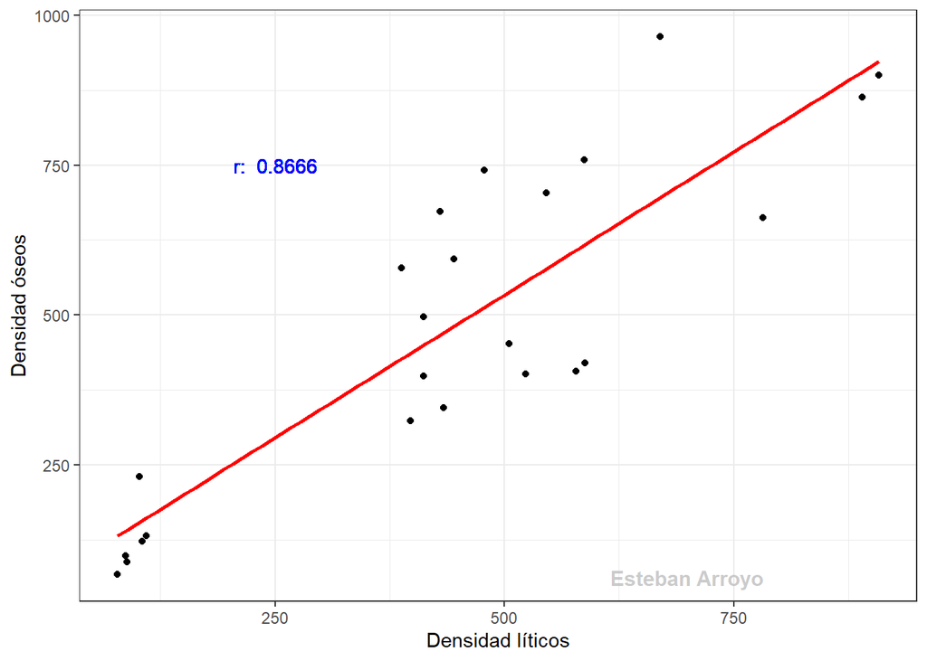

```r
ggplot(data_set1, aes(x = `Densidad líticos`, y = `Densidad óseos`)) + geom_point() + stat_smooth(method = "lm", formula = y ~ x, col = "red", se = FALSE) + theme_bw() + annotate("text",x=Inf,y=-Inf,label="Esteban Arroyo",hjust=2,vjust=-1,col="grey",cex=4,fontface = "bold", alpha = 0.8) + geom_text(x = 250, y = 750, label = paste("r: ", round(cor3$estimate, 4)), col="blue"  )
```

### Ahora hacemos el modelo de regresión

```r
reglineal1 <- lm(`Densidad óseos`~`Densidad líticos`, data=data_set1)
```

### Visualizamos nuestro modelos

```r
reglineal1 %>% as_flextable() %>%
  set_caption("Regresión Lineal de la densidad de restos óseos en base a la densidad de líticos") %>%
  bg(bg="#2874A6", part = "header") %>% bold(part = "header") %>%
  color(color = "white", part = "header") %>%
  add_footer_lines("Fuente: Esteban Arroyo") %>% autofit()
```

Regresión Lineal de la densidad de restos óseos en base a la densidad de líticos

|  | Estimate | Standard Error | t value | Pr(>\|t\|) |  |
| --- | --- | --- | --- | --- | --- |
| (Intercept) | 56.881 | 58.662 | 0.970 | 0.3428 |  |
| `Densidad líticos` | 0.953 | 0.117 | 8.147 | 0.0000 | *** |

Signif. codes: 0 <= '***' < 0.001 < '**' < 0.01 < '*' < 0.05  
Residual standard error: 138.4 on 22 degrees of freedom  
Multiple R-squared: 0.751, Adjusted R-squared: 0.7397  
F-statistic: 66.37 on 22 and 1 DF, p-value: 0.0000  
Fuente: Esteban Arroyo

### Verificamos los supuestos

```r
# test Jarque--Bera de normalidad
jarqueberaTest(reglineal1$residuals)
```

```
##
## Title:
##  Jarque - Bera Normalality Test
##
## Test Results:
##   STATISTIC:
##     X-squared: 1.4472
##   P VALUE:
##     Asymptotic p Value: 0.485
##
## Description:
##  Fri Oct 21 18:22:55 2022 by user: usuario
```

```r
# test de autocorrelation Durbin-Watson
dwtest(reglineal1)
```

```
##
##  Durbin-Watson test
##
## data:  reglineal1
## DW = 0.84736, p-value = 0.0003349
## alternative hypothesis: true autocorrelation is greater than 0
```

```r
# test de heterocedasticidad de Breusch-Pagan
bptest(reglineal1)
```

```
##
##  studentized Breusch-Pagan test
##
## data:  reglineal1
## BP = 2.8115, df = 1, p-value = 0.09359
```

### Observamos que los datos se ajustan a la normal y a la homocedasticidad. Sin embargo encontramos que existe autocorrelación positiva. Ahora bien, El estadístico de Durbin-Watson no proporciona datos fiables si la muestra tiene un tamaño pequeño (como en este caso), además los datos deben estar condicionados por una variable temporal o serializados en el tiempo, cosa que aquí no ocurre, o no al menos de manera directa, ya que efectivamente los “niveles” los pudieramos considerar como una variable de “tiempo”, no se está incluyendo en el modelo de regresión. Por tanto, y aunque no sería necesario considerar la autocorrelación, podemos hacer el ejercicio de corregir este problema con el metodo de Cochrane-Orcutt del paquete “orcutt”.

### Podemos ver la autocorrelación por la forma gráfica de la dispersión de los residuos

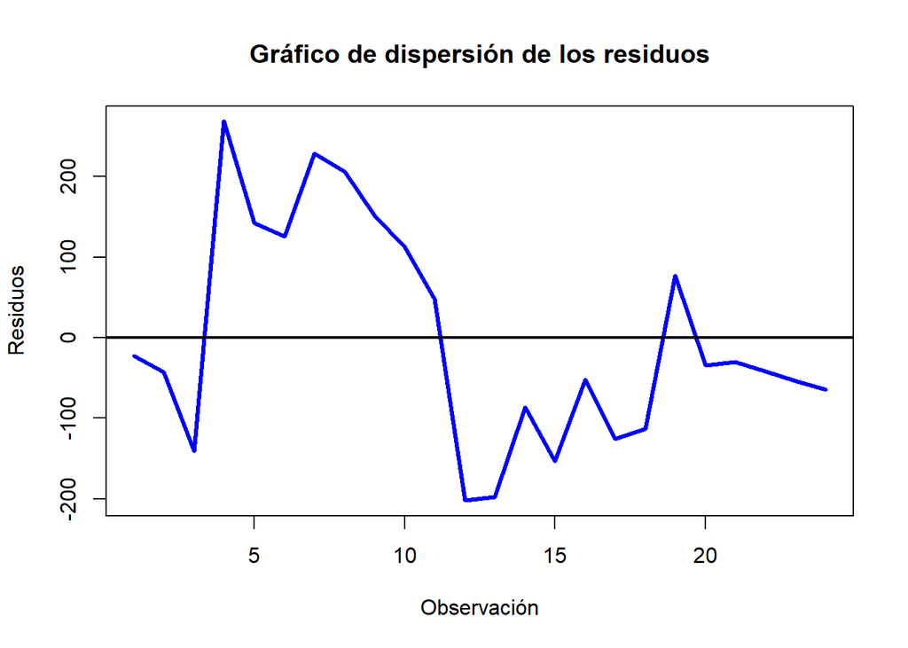

```r
res <- reglineal1$residuals
plot(res, type="l", ylab="Residuos", xlab="Observación", col="blue", lwd=3, main="Gráfico de dispersión de los residuos")
abline(h=0, col="black", lwd=2)
```

### Procedemos a Instalar y llamar al paquete “orcutt” para la Corrección de autocorrelación

```r
#install.packages("orcutt")
library(orcutt)
```

### Ejecutamos la función cochrane.orcutt() sobre nuestro modelo de regresión

```r
coch1 <- cochrane.orcutt(reglineal1)
coch1
```

```
## Cochrane-orcutt estimation for first order autocorrelation
##
## Call:
## lm(formula = `Densidad óseos` ~ `Densidad líticos`, data = data_set1)
##
##  number of interaction: 66
##  rho 0.927232
##
## Durbin-Watson statistic
## (original):    0.84736 , p-value: 3.349e-04
## (transformed): 2.99387 , p-value: 9.952e-01
##
##  coefficients:
##        (Intercept) `Densidad líticos`
##          -4.578433          -0.009556
```

### Podemos ver como se ajustan los coeficiente y cambia el valor del test Durbin-Watson

### Probamos nuevamente los supuestos con el ajuste de Cochrane-Orcutt

```r
jb <- jarqueberaTest(coch1$residuals) # Guardamos el test en un objeto
#testjb <- jb@test$statistic     #Extraemos el test y lo guardamos en un vector
#pvaluejb <- jb@test$p.value     #Extraemos el p-valor y lo guardamos en un vector
#jb_dataframe <- data.frame("Statistic"=testjb, "p.value"=pvaluejb)  #Con los vectores creamos un data frame

jb_dataframe <- data.frame("Statistic"=jb@test$statistic, "p.value"=jb@test$p.value, "Method"=jb@test$method)

#Ahora si funciona el flextable
jb_dataframe %>% flextable() %>% set_caption("Modelo Densidad Óseo vs Densidad Liticos") %>% bg(bg="#0000FF", part = "header") %>% bold(part = "header") %>% color(color = "white", part = "header") %>% autofit()
```

Modelo Densidad Óseo vs Densidad Liticos

| Statistic | p.value | Method |
| --- | --- | --- |
| 1.098581 | 0.5773594 | Jarque Bera Test |

```r
bptest(coch1$model) %>% as_flextable() %>% set_caption("Modelo Densidad Óseo vs Densidad Liticos") %>% colformat_double(j= ~ statistic, digits = 3) %>% bg(bg="#0000FF", part = "header") %>% bold(part = "header") %>% color(color = "white", part = "header") %>% autofit()
```

Modelo Densidad Óseo vs Densidad Liticos

| statistic | p.value | parameter | method |
| --- | --- | --- | --- |
| 0.786 | 0.3753 | 1.0 | studentized Breusch-Pagan test |

Signif. codes: 0 <= '***' < 0.001 < '**' < 0.01 < '*' < 0.05

```r
dwtest(coch1$model) %>% as_flextable() %>% set_caption("Modelo Densidad Óseo vs Densidad Liticos") %>% colformat_double(j= ~ statistic, digits = 3) %>% bg(bg="#0000FF", part = "header") %>% bold(part = "header") %>% color(color = "white", part = "header") %>% autofit()
```

Modelo Densidad Óseo vs Densidad Liticos

| statistic | p.value | method | alternative |
| --- | --- | --- | --- |
| 2.994 | 0.9952 | Durbin-Watson test | true autocorrelation is greater than 0 |

Signif. codes: 0 <= '***' < 0.001 < '**' < 0.01 < '*' < 0.05

### Observamos que ahora si tenemos todos los test ajustados y los nuevos coeficientes a usar en el modelo de regresión son:

## **restos óseos = -4.578433 + Densidad líticos*-0.009556**

```r
library(janitor)
tabyl(coch1$coefficients) %>% remove_constant() %>% flextable() %>%
  set_header_labels("coch1$coefficients" = "Coefficients") %>%
  append_chunks(i = c(1, 2), j=1, as_chunk(c(" (a)", " (b)"))) %>%
  bg(bg="#092ED6", part = "header") %>% bold(part = "header") %>%
  color(color = "white", part = "header") %>%  autofit()
```

| Coefficients |
| --- |
| -4.578433395 (a) |
| -0.009556042 (b) |

## **Ejercicio 2**

### En la hoja “Sitios” se encuentra la información de 30 sitios arqueológicos que se encuentran en las inmediaciones de una cantera de obsidiana. Para cada uno de estos sitios, se ha registrado su distancia lineal a la fuente, su altitud, y la proporción de obsidiana dentro de sus conjuntos líticos. Nos interesa saber si el porcentaje de obsidiana de los sitios puede ser predicho a partir de alguna de las otras dos variables. Para lo anterior, efectúe lo siguiente:

### a) Desarrolle dos modelos de regresión lineal, utilizando respectivamente para cada uno de ellos las variables altitud y distancia como independientes.

### En este caso como todas variables son contínuas numéricas, comprobamos la normalidad de los datos

```r
lillie.test(data_set2$`Dist(km)`) %>% as_flextable() %>%
  set_caption("Prueba de Normalidad Lilliefors (Kolmogorov-Smirnov) para Distancia (Kms)")%>%
  bg(bg="#9D4BE1", part = "header") %>% bold(part = "header") %>%
  colformat_double(j= ~ statistic, digits = 4)%>%
  add_footer_lines("Fuente: Esteban Arroyo") %>% autofit()
```

Prueba de Normalidad Lilliefors (Kolmogorov-Smirnov) para Distancia (Kms)

| statistic | p.value | method |
| --- | --- | --- |
| 0.0843 | 0.8472 | Lilliefors (Kolmogorov-Smirnov) normality test |

Signif. codes: 0 <= '***' < 0.001 < '**' < 0.01 < '*' < 0.05  
Fuente: Esteban Arroyo

```r
lillie.test(data_set2$`Altitud (msnm)`) %>% as_flextable() %>%
  set_caption("Prueba de Normalidad Lilliefors (Kolmogorov-Smirnov) para Altitud (msnm)")%>%
  bg(bg="#9D4BE1", part = "header") %>% bold(part = "header") %>%
  colformat_double(j= ~ statistic, digits = 4)%>%
  add_footer_lines("Fuente: Esteban Arroyo") %>% autofit()
```

Prueba de Normalidad Lilliefors (Kolmogorov-Smirnov) para Altitud (msnm)

| statistic | p.value | method |
| --- | --- | --- |
| 0.1085 | 0.4898 | Lilliefors (Kolmogorov-Smirnov) normality test |

Signif. codes: 0 <= '***' < 0.001 < '**' < 0.01 < '*' < 0.05  
Fuente: Esteban Arroyo

```r
lillie.test(data_set2$`%Obs`) %>% as_flextable() %>%
  set_caption("Prueba de Normalidad Lilliefors (Kolmogorov-Smirnov) para Obsidiana (%)")%>%
  bg(bg="#9D4BE1", part = "header") %>% bold(part = "header") %>%
  colformat_double(j= ~ statistic, digits = 4)%>%
  add_footer_lines("Fuente: Esteban Arroyo") %>% autofit()
```

Prueba de Normalidad Lilliefors (Kolmogorov-Smirnov) para Obsidiana (%)

| statistic | p.value | method |
| --- | --- | --- |
| 0.0862 | 0.8246 | Lilliefors (Kolmogorov-Smirnov) normality test |

Signif. codes: 0 <= '***' < 0.001 < '**' < 0.01 < '*' < 0.05  
Fuente: Esteban Arroyo

### Com todas las variables se ajustan a la normal procedemos a realizar una matrix de correlación de Pearson

```r
correlacion <- cor(data_set2, method="pearson")
```

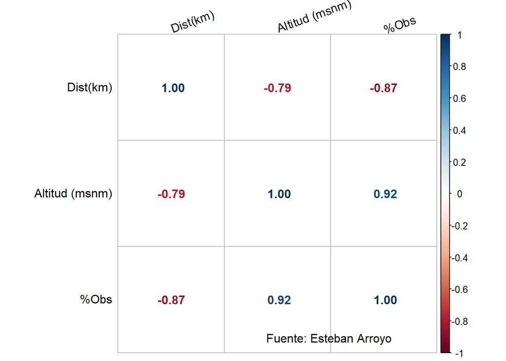

```r
library(corrplot)   #Con esto podemos hacer una representación gráfica de la correlación
corrplot(correlacion, method ="number", tl.col = "black", tl.srt = 20)
mtext("Fuente: Esteban Arroyo", side = 1, adj = 0.7, line=3)
```

### Ahora hacemos nuestros modelos de regresión usando respectivamente las variables altitud y distancia como independientes y la proporción de obsidiana como dependiente para cada uno.

```r
reglineal2 <- lm(`%Obs`~`Dist(km)`, data=data_set2)
reglineal3 <- lm(`%Obs`~`Altitud (msnm)`, data=data_set2)
```

### Ahora visualiamos nuestros modelos de regresión

```r
reglineal2 %>% as_flextable() %>%
  set_caption("Regresión Lineal de la Proporción de Obsidiana en base a la Distancia") %>%
  bg(bg="#154360", part = "header") %>% bold(part = "header") %>%
  color(color = "white", part = "header") %>%
  add_footer_lines("Fuente: Esteban Arroyo") %>% autofit()
```

Regresión Lineal de la Proporción de Obsidiana en base a la Distancia

|  | Estimate | Standard Error | t value | Pr(>\|t\|) |  |
| --- | --- | --- | --- | --- | --- |
| (Intercept) | 89.557 | 5.038 | 17.777 | 0.0000 | *** |
| `Dist(km)` | -0.456 | 0.049 | -9.390 | 0.0000 | *** |

Signif. codes: 0 <= '***' < 0.001 < '**' < 0.01 < '*' < 0.05  
Residual standard error: 13.11 on 28 degrees of freedom  
Multiple R-squared: 0.759, Adjusted R-squared: 0.7504  
F-statistic: 88.17 on 28 and 1 DF, p-value: 0.0000  
Fuente: Esteban Arroyo

```r
reglineal3 %>% as_flextable() %>%
  set_caption("Regresión Lineal de la Proporción de Obsidiana en base a la Altitud") %>%
  bg(bg="#154360", part = "header") %>% bold(part = "header") %>%
  color(color = "white", part = "header") %>%
  add_footer_lines("Fuente: Esteban Arroyo") %>% autofit()
```

Regresión Lineal de la Proporción de Obsidiana en base a la Altitud

|  | Estimate | Standard Error | t value | Pr(>\|t\|) |  |
| --- | --- | --- | --- | --- | --- |
| (Intercept) | 5.478 | 3.972 | 1.379 | 0.1788 |  |
| `Altitud (msnm)` | 0.022 | 0.002 | 12.238 | 0.0000 | *** |

Signif. codes: 0 <= '***' < 0.001 < '**' < 0.01 < '*' < 0.05  
Residual standard error: 10.6 on 28 degrees of freedom  
Multiple R-squared: 0.8425, Adjusted R-squared: 0.8369  
F-statistic: 149.8 on 28 and 1 DF, p-value: 0.0000  
Fuente: Esteban Arroyo

### b) Construya los gráficos que corresponden y compruebe los supuestos de la regresión a través de las herramientas vistas en clases, exponiendo también cada modelo mediante tablas que contengan la información ofrecida por R.

### Primero hacemos los gráficos de dispersión

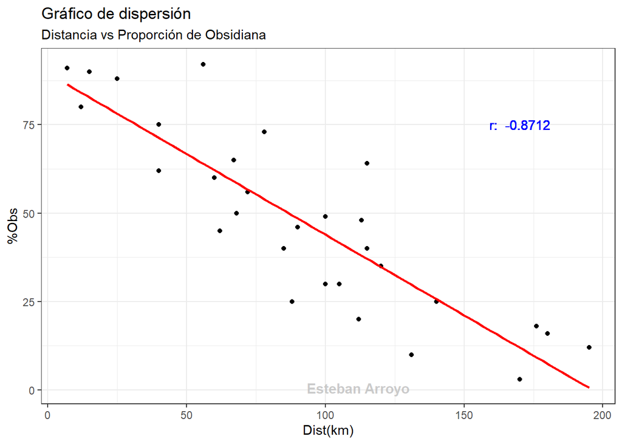

```r
cor4 <- cor.test(x=data_set2$`Dist(km)`, y=data_set2$`%Obs`, method="pearson")
ggplot(data_set2, aes(x = `Dist(km)`, y = `%Obs`)) + geom_point() + stat_smooth(method = "lm", formula = y ~ x, col = "red", se = FALSE) + theme_bw() + annotate("text",x=Inf,y=-Inf,label="Esteban Arroyo",hjust=3,vjust=-1,col="grey",cex=4,fontface = "bold", alpha = 0.8) + geom_text(x = 170, y = 75, label = paste("r: ", round(cor4$estimate, 4)), col="blue"  ) + ggtitle("Gráfico de dispersión", subtitle = "Distancia vs Proporción de Obsidiana")
```

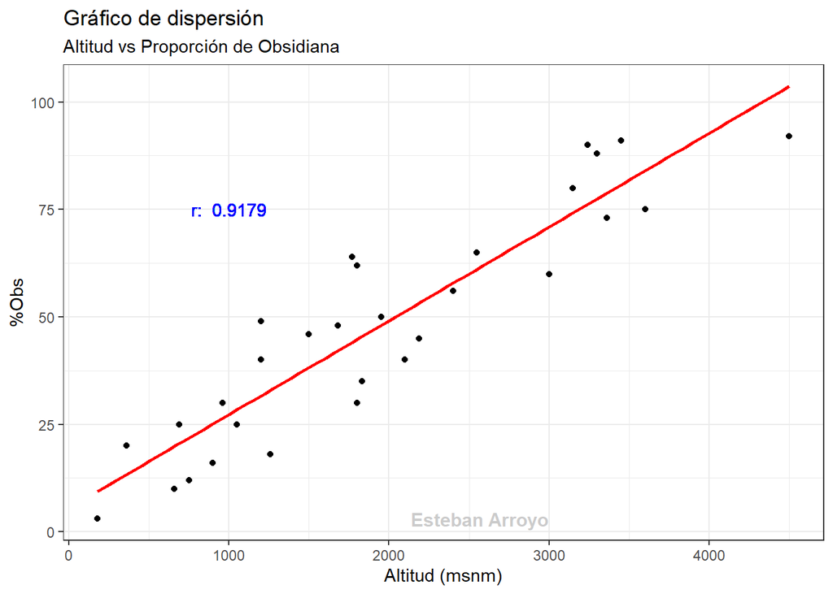

```r
cor5 <- cor.test(x=data_set2$`Altitud (msnm)`, y=data_set2$`%Obs`, method="pearson")
ggplot(data_set2, aes(x = `Altitud (msnm)`, y = `%Obs`)) + geom_point() + stat_smooth(method = "lm", formula = y ~ x, col = "red", se = FALSE) + theme_bw() + annotate("text",x=Inf,y=-Inf,label="Esteban Arroyo",hjust=3,vjust=-1,col="grey",cex=4,fontface = "bold", alpha = 0.8) + geom_text(x = 1000, y = 75, label = paste("r: ", round(cor5$estimate, 4)), col="blue"  ) + ggtitle("Gráfico de dispersión", subtitle = "Altitud vs Proporción de Obsidiana")
```

### Comprobamos los supuestos del modelo de Regresión Lineal de la Proporción de Obsidiana en base a la Distancia

```r
jb1 <- jarqueberaTest(reglineal2$residuals) # Guardamos el test en un objeto

jb_dataframe1 <- data.frame("Statistic"=jb1@test$statistic, "p.value"=jb1@test$p.value, "Method"=jb1@test$method)

#Ahora si funciona el flextable
jb_dataframe1 %>% flextable() %>% set_caption("Modelo Obsidiana vs Distancia") %>% bg(bg="#0000FF", part = "header") %>% bold(part = "header") %>% color(color = "white", part = "header") %>% autofit()
```

Modelo Obsidiana vs Distancia

| Statistic | p.value | Method |
| --- | --- | --- |
| 0.3297522 | 0.8479988 | Jarque Bera Test |

```r
bptest(reglineal2) %>% as_flextable() %>% set_caption("Modelo Obsidiana vs Distancia") %>% colformat_double(j= ~ statistic, digits = 3) %>% bg(bg="#0000FF", part = "header") %>% bold(part = "header") %>% color(color = "white", part = "header") %>% autofit()
```

Modelo Obsidiana vs Distancia

| statistic | p.value | parameter | method |
| --- | --- | --- | --- |
| 0.066 | 0.7967 | 1.0 | studentized Breusch-Pagan test |

Signif. codes: 0 <= '***' < 0.001 < '**' < 0.01 < '*' < 0.05

```r
dwtest(reglineal2) %>% as_flextable() %>% set_caption("Modelo Obsidiana vs Distancia") %>% colformat_double(j= ~ statistic, digits = 3) %>% bg(bg="#0000FF", part = "header") %>% bold(part = "header") %>% color(color = "white", part = "header") %>% autofit()
```

Modelo Obsidiana vs Distancia

| statistic | p.value | method | alternative |
| --- | --- | --- | --- |
| 1.695 | 0.1528 | Durbin-Watson test | true autocorrelation is greater than 0 |

Signif. codes: 0 <= '***' < 0.001 < '**' < 0.01 < '*' < 0.05

### Comprobamos los supuestos del modelo de Regresión Lineal de la Proporción de Obsidiana en base a la Altitud

```r
jb2 <- jarqueberaTest(reglineal3$residuals)

jb_dataframe2 <- data.frame("Statistic"=jb2@test$statistic, "p.value"=jb2@test$p.value, "Method"=jb2@test$method)

jb_dataframe2 %>% flextable() %>% set_caption("Modelo Obsidiana vs Altitud") %>% bg(bg="#0000FF", part = "header") %>% bold(part = "header") %>% color(color = "white", part = "header") %>% autofit()
```

Modelo Obsidiana vs Altitud

| Statistic | p.value | Method |
| --- | --- | --- |
| 2.029429 | 0.3625059 | Jarque Bera Test |

```r
bptest(reglineal3) %>% as_flextable() %>% set_caption("Modelo Obsidiana vs Altitud") %>% colformat_double(j= ~ statistic, digits = 3) %>% bg(bg="#0000FF", part = "header") %>% bold(part = "header") %>% color(color = "white", part = "header") %>% autofit()
```

Modelo Obsidiana vs Altitud

| statistic | p.value | parameter | method |
| --- | --- | --- | --- |
| 0.073 | 0.7865 | 1.0 | studentized Breusch-Pagan test |

Signif. codes: 0 <= '***' < 0.001 < '**' < 0.01 < '*' < 0.05

```r
dwtest(reglineal3) %>% as_flextable() %>% set_caption("Modelo Obsidiana vs Altitud") %>% colformat_double(j= ~ statistic, digits = 3) %>% bg(bg="#0000FF", part = "header") %>% bold(part = "header") %>% color(color = "white", part = "header") %>% autofit()
```

Modelo Obsidiana vs Altitud

| statistic | p.value | method | alternative |
| --- | --- | --- | --- |
| 1.521 | 0.0646 . | Durbin-Watson test | true autocorrelation is greater than 0 |

Signif. codes: 0 <= '***' < 0.001 < '**' < 0.01 < '*' < 0.05

### Podemos observar que los dos modelos se ajustan a los supuestos

### d) Refiérase al potencial de cada modelo para predecir el porcentaje de obsidiana en nuevos sitios del área.

### r:**-0.8712**, Adjusted R-squared: **0.7504** –> Proporción de Obsidiana en base a la Distancia

### r: **0.9179**, Adjusted R-squared: **0.8369** –> Proporción de Obsidiana en base a la Altitud

### En base a estos resultados, el mejor modelo para predecir el porcentaje de obsidiana es en base a la Altitud, dado que tienen la mejor correlación y el mejor coeficiente de determinación, indicando que que la Proporción de Obsidiana es explicada por la Altitud en un 84% aproximadamente.

### Por lo tanto, coeficientes a usar en el modelo de regresión son:

## **Proporción de Obsidiana = 5.478 + Altitud(msnm)*0.022**